# Time Series

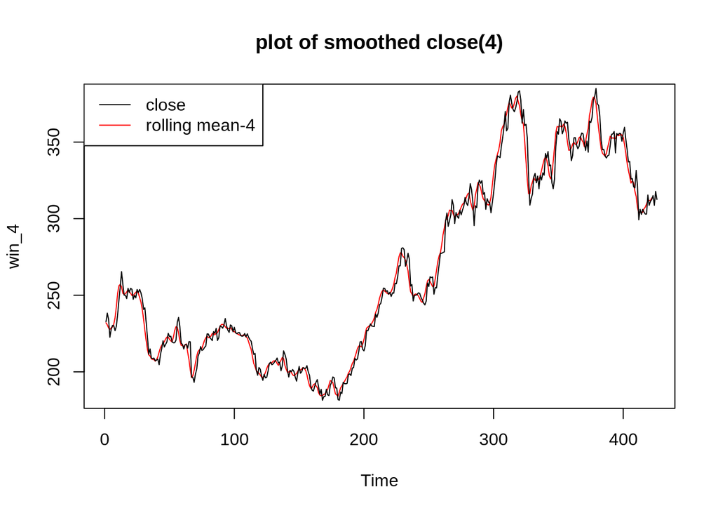

```r
 win_4<-rollapply(zoo(data$close), width = 4, FUN = mean, align = "left")
plot.ts(win_4,col='red', main="plot of smoothed close(4)")
lines(data$close, col='black')
legend("topleft",legend=c("close","rolling mean-4"),col=c("black","red"), lty=1:1)
```

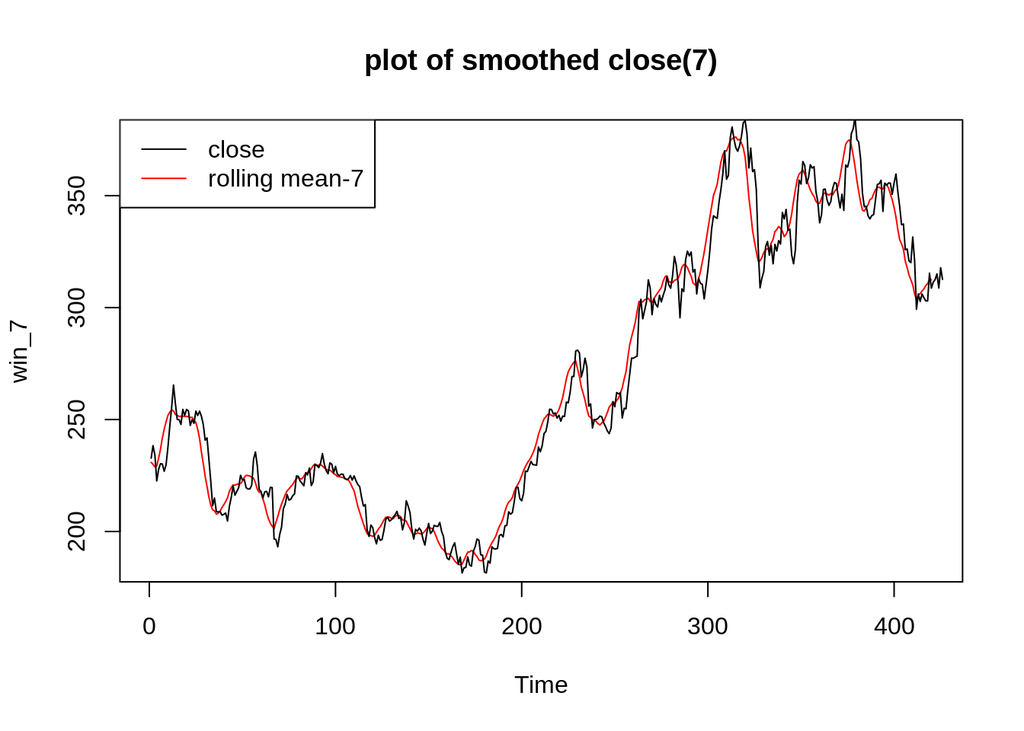

```r
win_7<-rollapply(zoo(data$close), width = 7, FUN = mean, align = "left")
plot.ts(win_7,col='red', main="plot of smoothed close(7)")
lines(data$close, col='black')
legend("topleft",legend=c("close","rolling mean-7"),col=c("black","red"), lty=1:1)
```

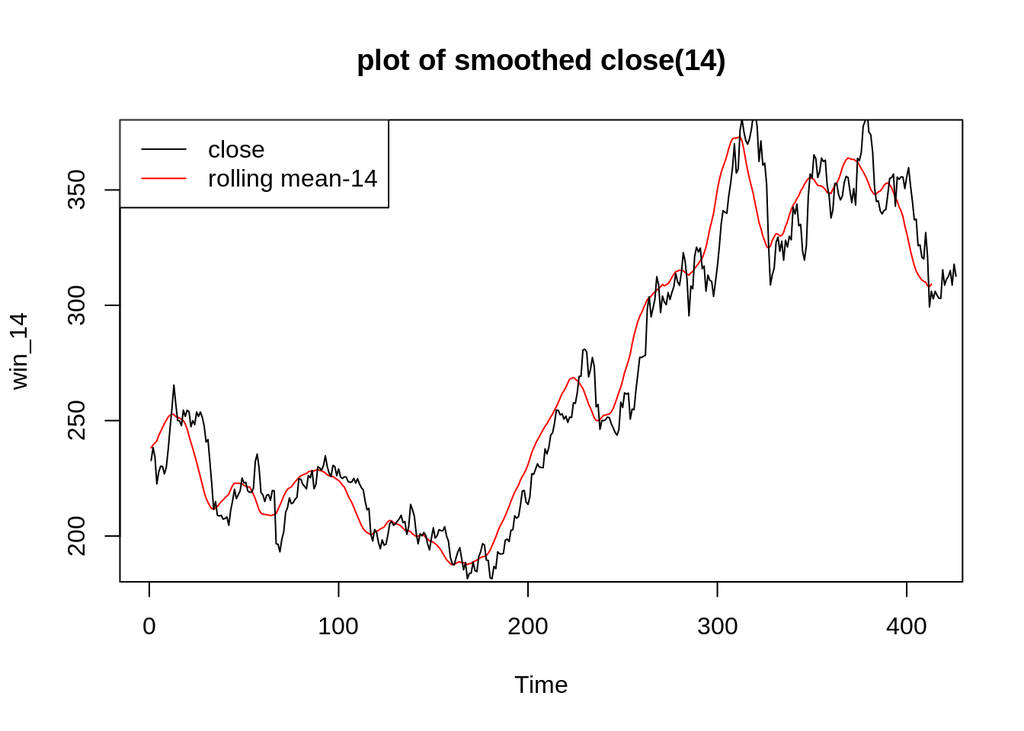

```r
 win_14<-rollapply(zoo(data$close), width = 14, FUN = mean, align = "left")
plot.ts(win_14,col='red', main="plot of smoothed close(14)")
lines(data$close, col='black')
legend("topleft",legend=c("close","rolling mean-14"),col=c("black","red"), lty=1:1)
```

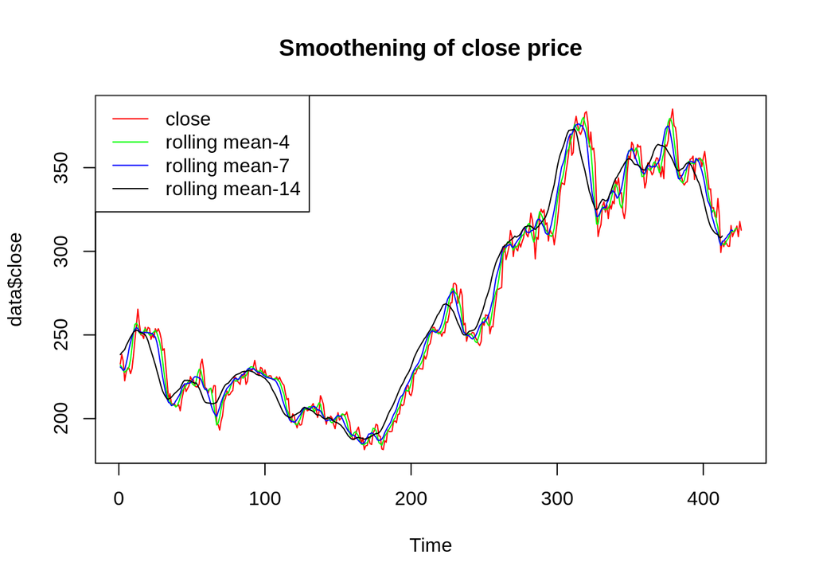

```r
 plot.ts(data$close,col='red', main="Smoothening of close price")
  lines(win_4, col='green')
  lines(win_7, col='blue')
  lines(win_14, col='black')
legend("topleft",legend=c("close","rolling mean-4","rolling mean-7","rolling mean-14"),col=c("red","green","blue","black"), lty=1:1)
```

When actual close values are plotted against data smoothed with window size=4,there still appears to be quite a lot of random fluctuations in the time series and it looks similar to actal data plotted.Thus, to estimate the trend component more accurately, we might want to try smoothing the data with a simple moving average of a higher order. When we go for wndow size=7 it shows better results but it can still be more accurately smoothed. Thus with window size=14, we see that most of the random fluctuations are gone and it gives a clearer picture of the trend component.

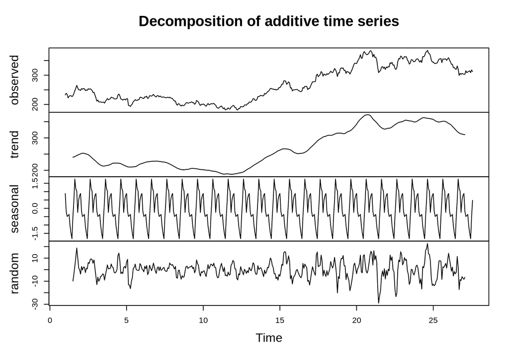

```r
d16 = ts(data$close, frequency = 16)
decompose_d16= decompose(d16, "additive")
plot(decompose_d16)
```

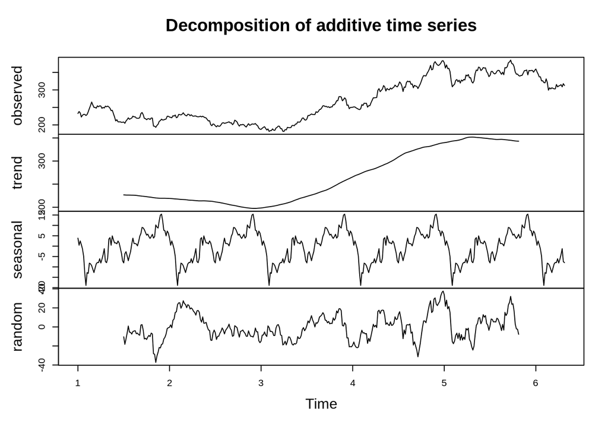

```r
 d80 = ts(data$close, frequency = 80)
decompose_d80= decompose(d80, "additive")
plot(decompose_d80)
```

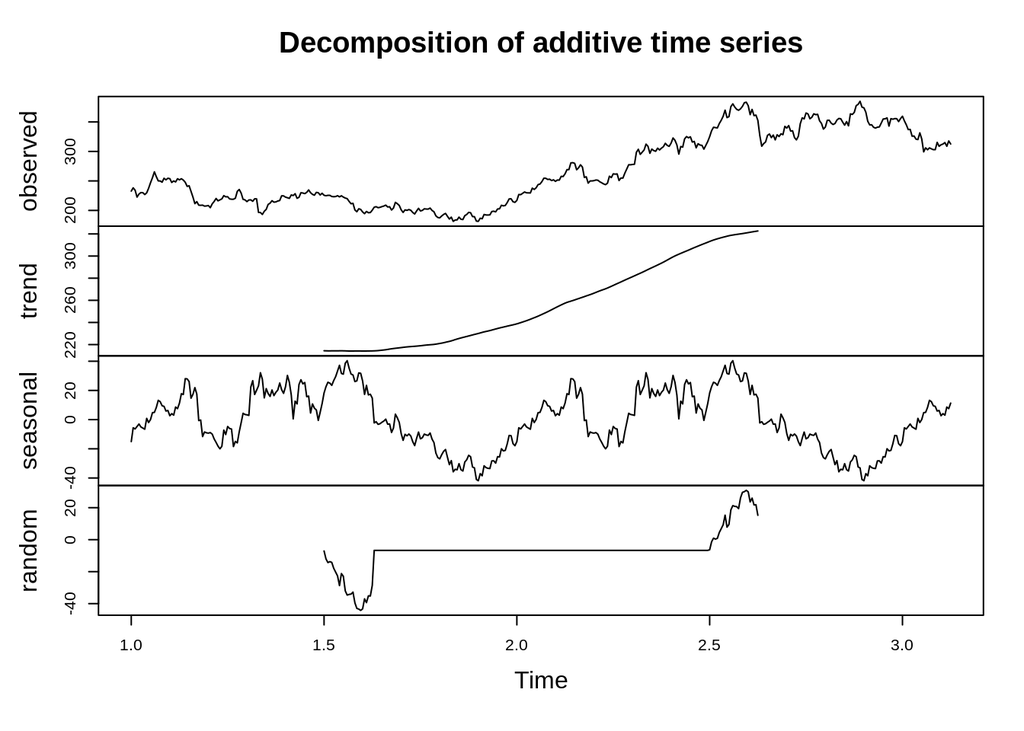

```r
d200 = ts(data$close, frequency = 200)
decompose_d200= decompose(d200, "additive")
plot(decompose_d200)
```

We can observe that smaller frequencies show smaller trends while higher frequency are not able to capture the trends and the pattern.Hence,smaller frequency may show smaller seasonal pattern and larger one shows larger seasonal pattern. So, the frequency 80 shows almost appropriate seasonality

The right seasonality of this time series seems to be represented with the frequency 80.

1. 1. Is the Closing price a stationary time series? Perform Augmented Dickey Fuller test to verify.

```r
adf<-adf.test(data$close)
print(adf)
```

```
##
##  Augmented Dickey-Fuller Test
##
## data:  data$close
## Dickey-Fuller = -2.0061, Lag order = 7, p-value = 0.575
## alternative hypothesis: stationary
```

```r
print(adf$p.value)
```

```
## [1] 0.5749541
```